# Bi e Analytics

Jean Maia

Temos o objetivo de ajudar a equipe de RH a antecipar-se aos desligamentos. Um dos pilares da companhia tornou-se buscar a longevidade dos funcionários. Para isto, vamos utilizar das quatro fases da Ciência de Dados: `Descritiva`, `Inferencial`, `Preditiva` e `Prescritiva`.

O dataset disponível ao nosso estudo pode ser encontrado em: https://www.kaggle.com/ludobenistant/hr-analytics/data. Descrito pelas seguintes variáveis:

| Variaveis | Descricao | Tipos |
| --- | --- | --- |
| satisfaction_level | Level of satisfaction (0-1) | Numeric |
| last_evaluation | Time since last performance evaluation (in Years) | Numeric |
| number_project | Number of projects completed while at work | Numeric |
| average_montly_hours | Average monthly hours at workplace | Numeric |
| time_spend_company | Number of years spent in the company | Numeric |
| Work_accident | Whether the employee had a workplace accident | Numeric |
| left | Whether the employee left the workplace or not (1 or 0) Factor | Numeric |
| promotion_last_5years | Whether the employee was promoted in the last five years | Numeric |
| sales | Department in which they work for | String |
| salary | Relative level of salary (high) | String |

# Descritiva

Vamos iniciar verificando informações gerais sobre o dataset

#### Número de pessoas que pediram demissão ou foram desligadas.

```
##
##     0     1
## 11428  3571
```

#### Informações sobre o nível de satisfação

```
##    Min. 1st Qu.  Median    Mean 3rd Qu.    Max.
##  0.0900  0.4400  0.6400  0.6128  0.8200  1.0000
```

#### Informações sobre as horas de trabalho.

```
##    Min. 1st Qu.  Median    Mean 3rd Qu.    Max.
##    96.0   156.0   200.0   201.1   245.0   310.0
```

#### Informações sobre as áreas

```
##
##  accounting          hr          IT  management   marketing product_mng
##         767         739        1227         630         858         902
##       RandD       sales     support   technical
##         787        4140        2229        2720
```

#### Informações sobre os salários

```
##
##   high    low medium
##   1237   7316   6446
```

Vamos fazer projeções envolvendo mais variáveis. O Objetivo é verificar os padrões relacionados às saídas da empresa.

## Relação entre níveis de satisfação e horas mensais de trabalho

[interactive chart not shown]

## Relação entre anos de empresa e níveis de satisfação

[interactive chart not shown]

## Relação densidade entre níveís de satisfação e salário

[interactive chart not shown]

# Inferencial/diagnóstica

#### Inicialmente, apliquei testes de hipóteses para verificar quais variáveis eram importantes para o nossa proposta - saber quais pessoas irão sair.

#### Após aplicar T-test, verifiquei duas variáveis completamente desnecessárias ao objetivo: last_evaluation e number project. O que nos traz alguns indicativos.

`last_evaluation`: Implica em, sair da empresa é indiferente em relação as variações da última vez que o teste foi feito. As pessoas insatisfeitas tendem a continuar insatisfeitas, e as satisfeitas permanecem neste estado. O que implica em dois potenciais problemas: Problemas de gestão, ou problemas da cultura da empresa. Podemos repensar a cultura da empresa, ou ajustar o fluxo de contratação para recrutar profissionais melhores alinhados aos pilares da empresa.

`number_project`: Implica em, a quantidade de projetos desenvolvidos ao longo do trabalho, não é um indicativo de desejo de permanecer na empresa. Ou, mudanças contínuas de projeto não implicam em maior ou menor satisfação no trabalho. Isto pode ter relação com o perfil dos profissionais da área.

### Vamos descobrir quais as variáveis que mais se relacionam com o fato - sair da empresa.

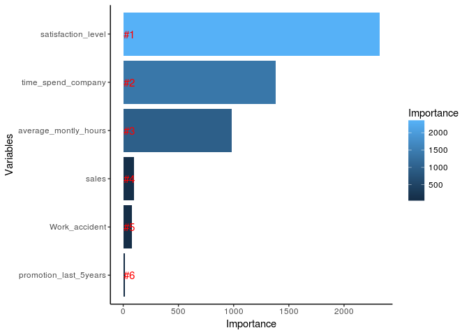

# Preditivo

### Após as fases descritivas e inferencias, foi possível criar um modelo preditivo com acurácia de 92%

[Modelo Preditivo](https://jeanmaia.shinyapps.io/DataSciencePurpose/)

# Prescritivo

Com a sucessão de todos os fatos, temos situações que são claramente sugeríveis.

A vontade de sair da empresa está relacionada com três fatores: `Satisfação`, `Média de horas trabalhadas por mês` e `Tempo de trabalho na empresa`. Explicitamente com baixos valores de satisfação, altas médias de horas trabalhadas por mês e pouco tempo de empresa.

Conseguimos perceber potenciais de evolução ao processo de recrutamento e seleção, e geramos um produto como saída.